# How Qualified Are Team Qualifiers?

Karl Holub karljholub@gmail.com

## About

In no state is high school Nordic skiing healthier than Minnesota. Our state houses ~100 teams and thousands of student skiers. The State Meet is the biggest event & goal of the year for the majority of those skiers. In such an environment, it is critical we foster fair competition, and that starts with State Meet qualification criteria. Currently:

- The top 2 teams per section qualify for the state meet, each team bringing 7 skiers
- The top 6 individual skiers not already qualified through a team also qualify

In team scoring, only the 4 best out of the team’s 7 skiers are counted. This means each team carries 3 skiers (those ranked 5 to 7 on their team) that won’t score at the state meet; how “qualified” are the 5-7 team qualifiers? Are they close to scoring for their team? Are they outperforming individual skiers at their sections meets?

Through 2020 results, we can discover that:

- 5-7 team qualifiers place at the bottom of the state meet, below individual qualifiers and most teams’ 4th place qualifier. This implies 5-7 qualifiers aren’t:
  - In contention to change scoring outcomes
  - Increasing the competitiveness of the state meet
- There are a large number of individuals at sections meets that outperform 5-7 team qualifiers but are not rewarded.

Both of which imply that changes to qualification, in favor of smaller teams and an increased number of individual qualifiers, may improve fairness and competitiveness of the state meet.

## Data

[2020 state meet](https://www.skinnyski.com/racing/highschool/2020/statemeet-expanded.pdf) and all sectional meet results were pulled from SkinnySki.com. Boys and girls are considered independently in each analysis.

## Analysis

### Where do 5-7 team qualifiers place at the state meet?

A heatmap visualizes the distribution of team qualifiers across the State Meet. Each bar in the chart is a skier, ordered by state meet placement. The color of the bar is the rank of the skier on their team; darker blue colors represent lower ranking within team, while grey indicates an individual qualifier.

#### Boys

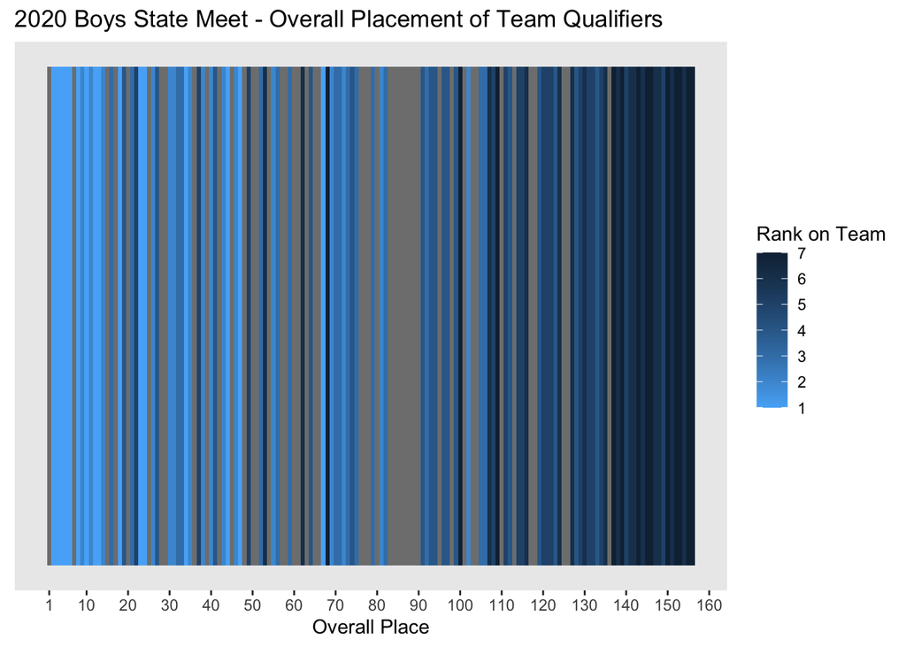

In general, individual qualifiers and high team qualifiers fill the front of the field, while the 5-7 team qualifiers fill the back. In fact, the **bottom 20 skiers in this meet were entirely 5-7 qualifiers**. Comparing average overall place with ranking within team:

| Rank on Team | Average Overall Place |
| --- | --- |
| 1 | 20.0000 |
| 2 | 43.8750 |
| 3 | 63.8750 |
| 4 | 88.1250 |
| 5 | 108.3750 |
| 6 | 126.1875 |
| 7 | 134.8462 |

5th ranked team qualifiers averaged 108th place in the state meet, which is the bottom 31% of the field. The 6th ranked team qualifier averaged bottom 19% of the field.

#### Girls

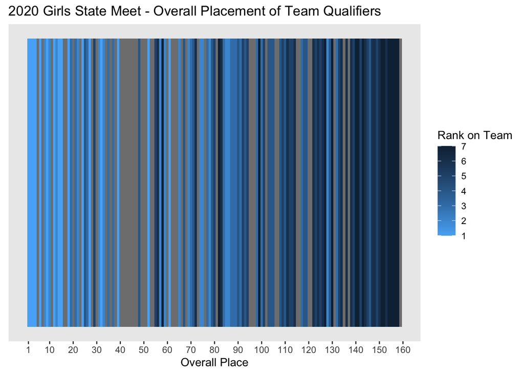

The girls show a similar trend as the boys, with the back end of the field predominated by 5-7 qualifiers. Comparing average overall placement with team ranking:

| Ranking on Team | Average Overall Placement |
| --- | --- |
| 1 | 19.9375 |
| 2 | 55.8125 |
| 3 | 73.1875 |
| 4 | 94.6875 |
| 5 | 108.8125 |
| 6 | 122.3750 |
| 7 | 133.5333 |

Similar to the boys, 5th ranked team qualifiers averaged 108th place, which is the bottom 32% of the field. The 6th ranked team qualifiers average the bottom 23% of the field.

### Could 5-7 team qualifiers be replaced by individual qualifiers?

Section meet data is used to find the number of non-qualifying individual skiers that outperformed the 5-7 team qualifiers. Specifically, placement and time gaps between the last individual qualifier and the 5/6/7 team qualifiers are analyzed. These numbers may go negative (i.e. a 5th team qualifier outperforms individual qualifiers) in sections with deep teams.

#### Boys

Each column of the below table represents the gap between the last (6th) individual qualifier and a team’s 5th/6th/7th qualifier. For example, if in section 1, if the last individual qualifier was 13th overall, and the winning team’s 5th ranked qualifier was 17th, the table entry would be “4”.

| Section | Places between Last Individual and 5th Team Qualifiers | Places between Last Individual and 6th Team Qualifiers | Places between Last Individual and 7th Team Qualifiers |
| --- | --- | --- | --- |
| 1 | 6 | 9 | 16 |
| 2 | 2 | 8 | 14 |
| 3 | 0 | 6 | 8 |
| 4 | 0 | 7 | 9 |
| 5 | 8 | 15 | 24 |
| 6 | 4 | 6 | 12 |
| 7 | 2 | 10 | 16 |
| 8 | 10 | 23 | 36 |

| Places between Last Individual and 5th Team Qualifiers | Places between Last Individual and 6th Team Qualifiers | Places between Last Individual and 7th Team Qualifiers |
| --- | --- | --- |
| 4 | 10 | 17 |

Across all sections, an average of 4 individual skiers that did not qualify for the state meet placed better than the 5th ranked team qualifiers. The average pursuit time gap between the last individual qualifier and the the 5th ranked team qualifier was a substantial 29.7 seconds. This story gets worse for lower team qualifiers, inflating to **17 individual skiers outperforming 7th ranked team qualifiers**.

#### Girls

| Section | Places between Last Individual and 5th Team Qualifiers | Places between Last Individual and 6th Team Qualifiers | Places between Last Individual and 7th Team Qualifiers |
| --- | --- | --- | --- |
| 1 | 18 | 20 | 22 |
| 2 | 12 | 16 | 19 |
| 3 | 0 | 4 | 9 |
| 4 | -4 | -2 | -2 |
| 5 | 14 | 21 | 26 |
| 6 | 3 | 5 | 7 |
| 7 | 7 | 9 | 11 |
| 8 | 4 | 12 | 19 |

The deep and competitive section 4 again shows team qualifiers outperforming individual qualifiers; however, the typical case is that team qualifiers are vastly outperformed by individual qualifiers. Averaging over sections looks similar to the boys:

| Places between Last Individual and 5th Team Qualifiers | Places between Last Individual and 6th Team Qualifiers | Places between Last Individual and 7th Team Qualifiers |
| --- | --- | --- |
| 7 | 11 | 14 |

## Conclusions

Occassionally 5th ranked team qualifiers outperform the last individual qualifier. In only one instance (section 4 girls) do 6th ranked team qualifiers also outperform the last individual. These findings indicate that qualifying team size could be shrunk to 5 skiers with little impact on team competitiveness, while bolstering the State Meet competition level and equitability.

## Disclaimer

The author is a coach at Irondale High School. All data and code generating this document are available [here](https://github.com/holub008/snippets/blob/master/mn_hs_ski_sections/team_size_analysis.Rmd).